# Introduction of SwissAnalysis APP

26/10/2020

## Introduction

This is a short presentation of APP **swissAnalysis**. This APP provides simple analysis of the dataset *swiss*, which contains the information of standardized fertility measure and socio-economic indicators for each of 47 French-speaking provinces of Switzerland at about 1888.

The APP could be accessed from https://zz7sp.shinyapps.io/swissanalysis

The original code of **the APP and this presentation** could be access from https://github.com/7cats/DataProductW4

## Functions of the APP

This APP has three basic functions:

1. Plotting the relation between two variables, which are chosen by users.
2. Generating fitted regression model for the **whole data set**, or a **subset of the dataset** which the users should select from the plot.
3. Giving the **\(R^2\)** of fitted regression models.

## Input and the reactive output

- If the **box** of *Fit a regression model* is ticked, the APP will generate a linear regression model and plot the fitted line.
- If **a subset of the data are selected from the plot**, the APP will generate another linear regression model using this subset of data.
- The **\(R^2\)** of fitted model will be presented below the plot, when box is ticked and area is selected from the plot.

## Example of Fertility and Agriculture:

If **Fertility** and **Agriculture** are chosen are variables to be analyzed (which is the default setting), and a small area are selected, the APP will present this result.

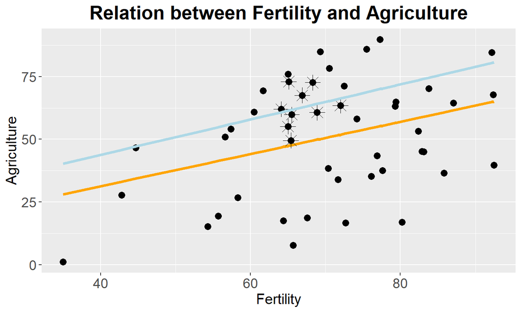